# The Normal Distribution

TEMBA Statistics 2026

## Normal distributions have two parameters

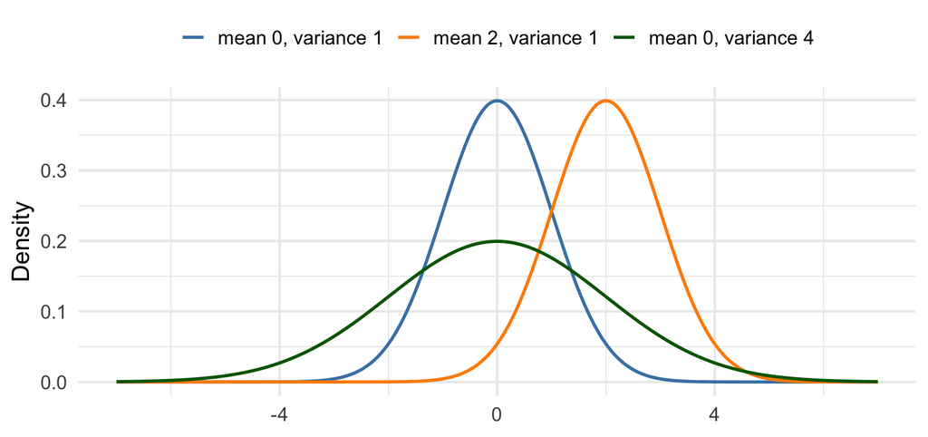

Changing $\mu$ slides the curve without altering its shape; changing $\sigma^2$ stretches or squeezes it without moving the center. The distribution is symmetric, so its mean and median are equal.

## Notation

**Notation: the normal distribution**

$$X \sim N(\mu, \sigma^2)$$

“$\sim$” reads “is distributed as.” **The second parameter is the variance, not the standard deviation** — though R’s `pnorm` and `qnorm` ask for the standard deviation.

A shifted and scaled normal random variable is still normal: $aX + b \sim N(a\mu + b,\; a^2\sigma^2)$.

**Quick check:** If $X\sim N(500,80^2)$, identify its mean, variance, and standard deviation. Which two values would you give software that asks for the mean and standard deviation?

## Modeling weekly market returns

We model next week’s S&P 500 return $R$ as normal, using the historical mean and standard deviation as parameters. The fitted model is $R \sim N(0.0047, 0.0212^2)$.

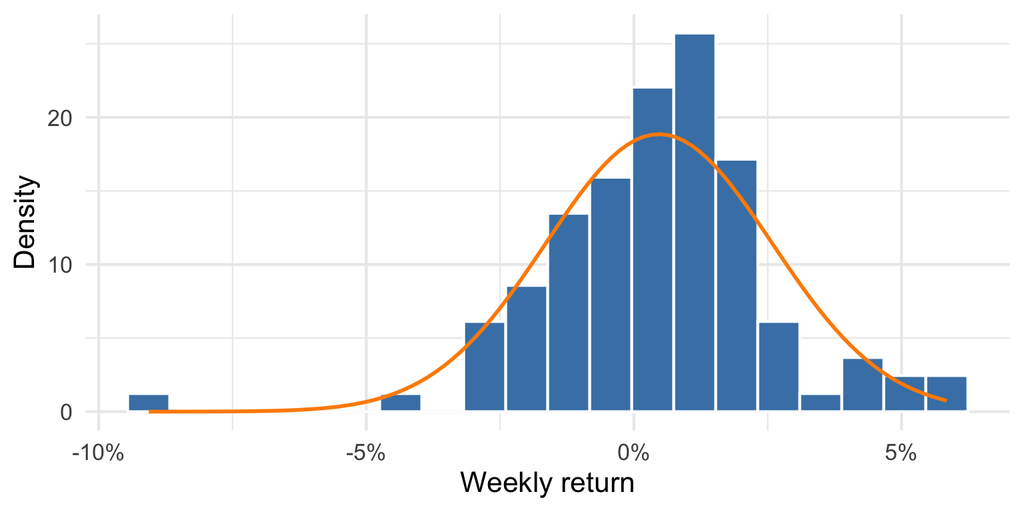

Weekly returns are not literally normal. We use the normal distribution as an approximation in the region we care about, and we check that approximation against the data below.

## Probabilities are areas

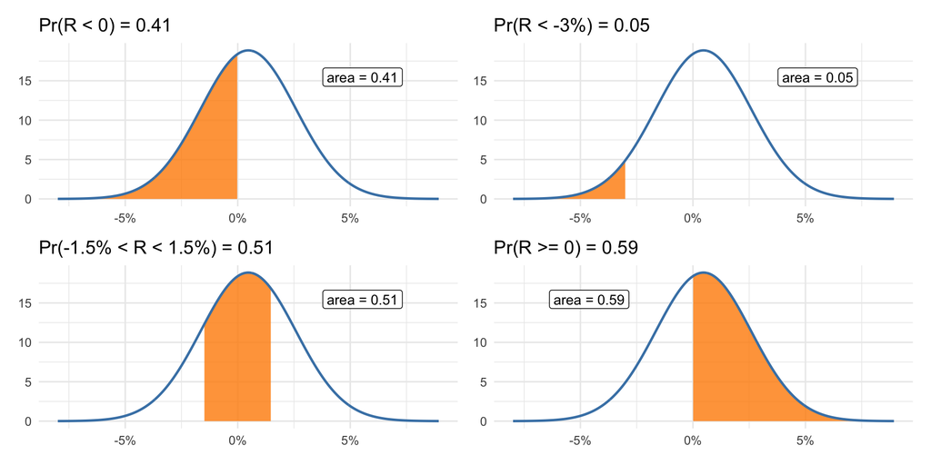

## Interval probabilities, two ways

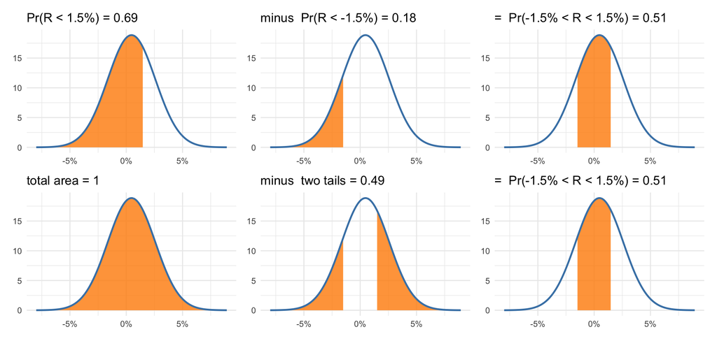

The top row subtracts the left tail. The bottom row subtracts both outside tails from 1. Both calculations give the same interval probability.

## Service-time probabilities

A logistics team models delivery time as $T\sim N(42,9^2)$ minutes. Sketch the areas for $\Pr(T>60)$ and $\Pr(35<T<50)$, then write each calculation using $F_T$.

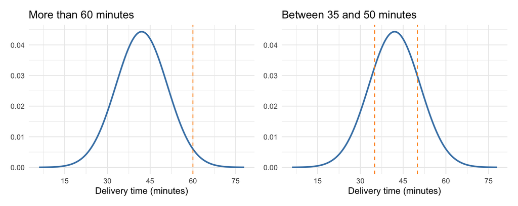

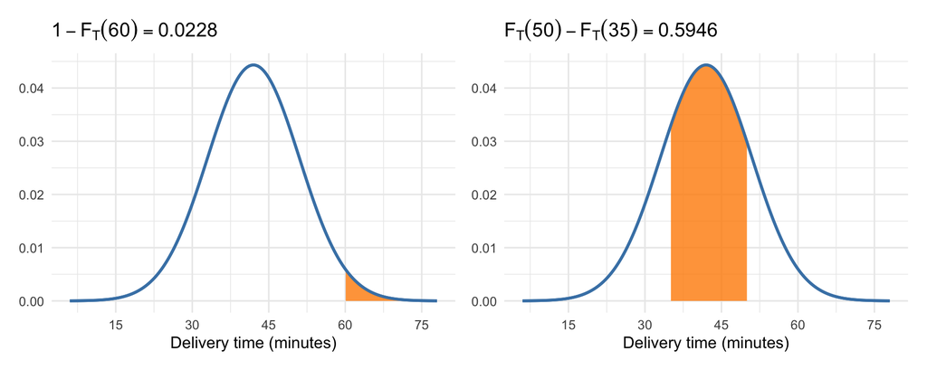

## The 68/95/99.7 rule

**The 68/95/99.7 rule**

If $X \sim N(\mu, \sigma^2)$, approximately

- **68%** of the probability lies within $\mu \pm \sigma$.
- Approximately **95%** lies within $\mu \pm 2\sigma$.
- Approximately **99.7%** lies within $\mu \pm 3\sigma$.

Under this model, a $-4\%$ week is 2.11 standard deviations below the mean. Its lower-tail probability is 0.017, or about once per 58 weeks.

## The rule on the returns model

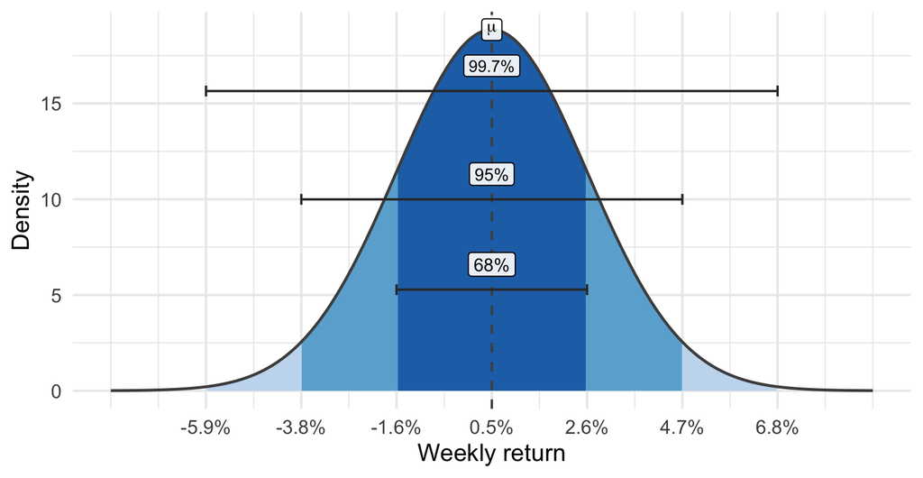

About two weeks in three land within one standard deviation of the mean, and about 19 in 20 within two.

## Z-scores, again

- Standardizing a normal random variable gives the **standard normal**: $Z = \frac{X - \mu}{\sigma} \sim N(0, 1)$.
- A normal random variable lands more than 2 standard deviations out about 5% of the time, and more than 3 out about 0.3% of the time.
- In our 104 weeks of data, 6 fall beyond two standard deviations, where the model expects about five. We observe 1 beyond three standard deviations, where the model expects about 0.3. Both counts are consistent with sampling variation in a sample this small.

## Z-scores and normal probabilities

**Z-scores and normal probabilities**

A z-score translates to probabilities *only when the underlying random variable is normal*. Under a normal model, $|Z| \geq 2.5$ occurs about once in 80 observations; under a heavy-tailed model it can occur much more often.

## What a z-score does and does not tell us

A strongly right-skewed measure of engineering productivity has mean 420 and standard deviation 500. One engineer’s observed value is 1,420.

1. Calculate and interpret the z-score.
2. Can a normal table or normal-distribution software determine the probability of a value at least this large?

$$z=\frac{1{,}420-420}{500}=2.$$

The observation is two standard deviations above the mean. That interpretation is valid for any distribution, but the strongly right-skewed shape does not justify a normal tail probability.

## QQ plots: checking normality

- A **quantile-quantile (QQ) plot** plots observed quantiles against the corresponding theoretical normal quantiles.
- Data that are truly close to normal trace a straight line.
- Where the points bend away from the line tells us how the data differ from a normal distribution. The examples below show the common patterns.

## Comparing distributions percentile by percentile

One way to compare two distributions is to ask whether they share the same percentiles. Half of a standard normal falls below 0, so we check whether half of the z-scored returns do too.

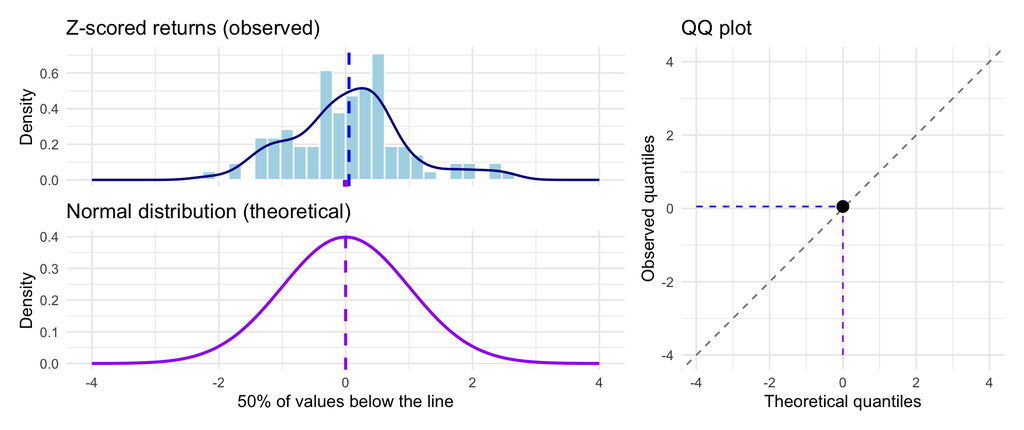

Blue marks the median of the returns, purple the median of the normal; the pair is the first point on the QQ plot.

## The 75th percentile adds a point

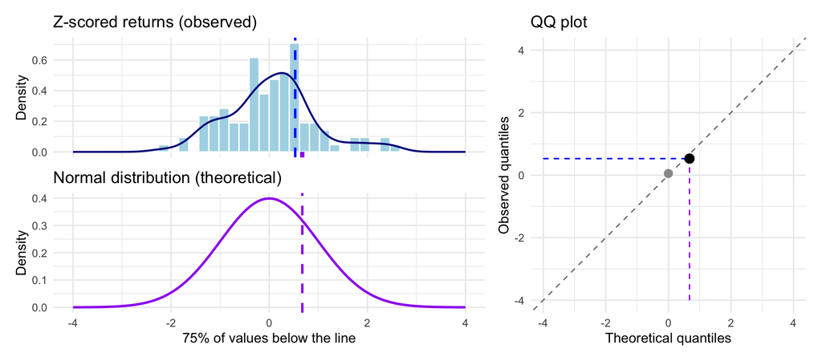

Blue and purple now mark the 75th percentile of each distribution, giving a second point.

## The 10th percentile adds another

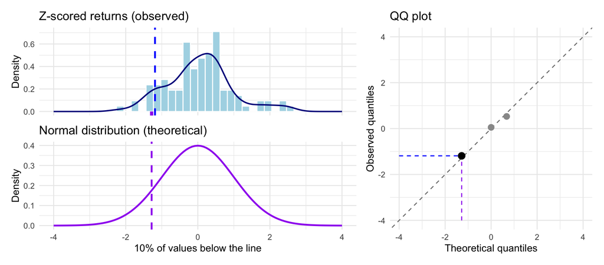

Blue and purple mark the 10th percentile; each comparison we make lands one more point.

## Every percentile becomes a point

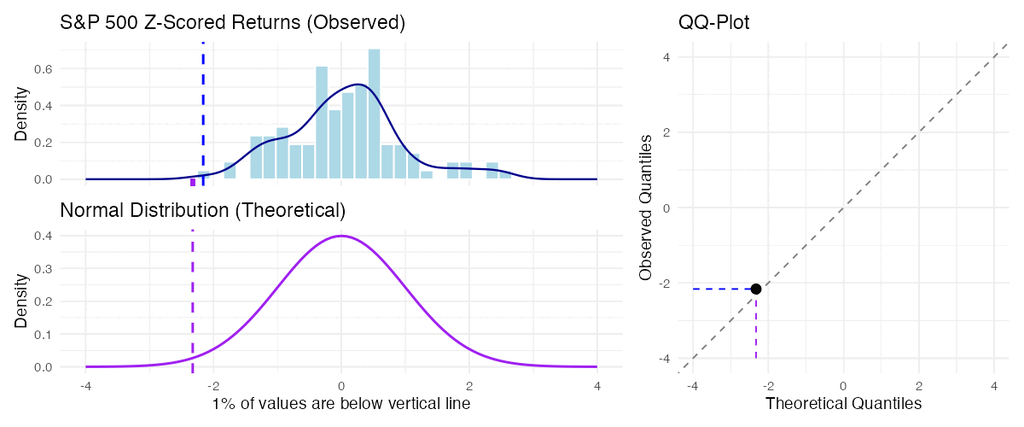

Sweeping from the 1st percentile to the 99th traces the whole curve — close to the reference line here, except at the extremes.

## Even normal data wobbles

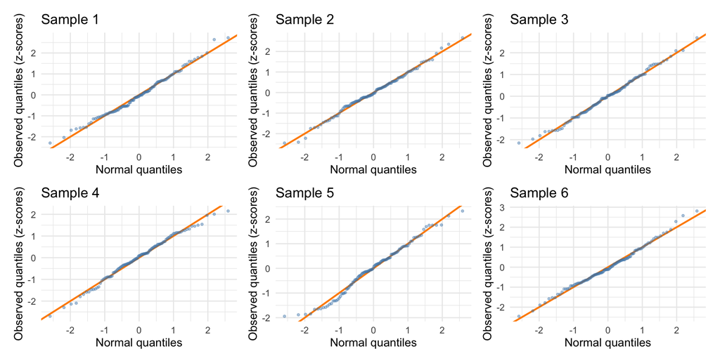

These six simulated datasets have the same size as the returns data (n = 104) and come from a normal distribution. Deviations of this size are consistent with sampling variation. Sustained departures from the line provide evidence against normality.

## QQ plot: weekly market returns

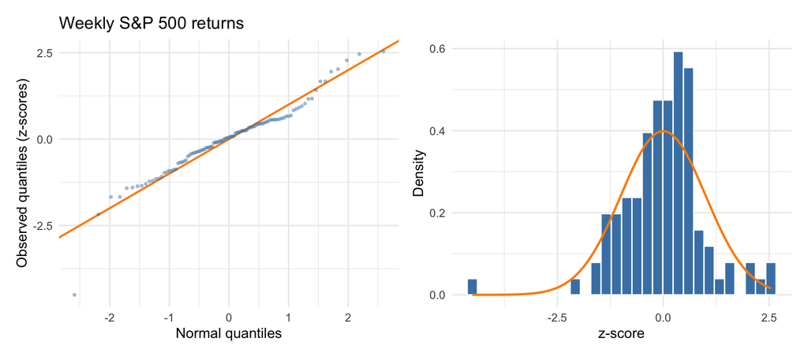

## QQ plot: hourly wages

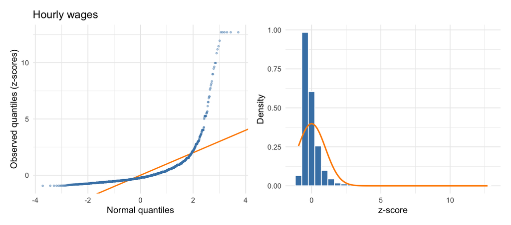

At the top of the plot, observed wages lie well above the corresponding normal quantiles. The sustained upward departure indicates strong right skew; the flat run at the very top comes from capped reported earnings.

## QQ plot: log hourly wages

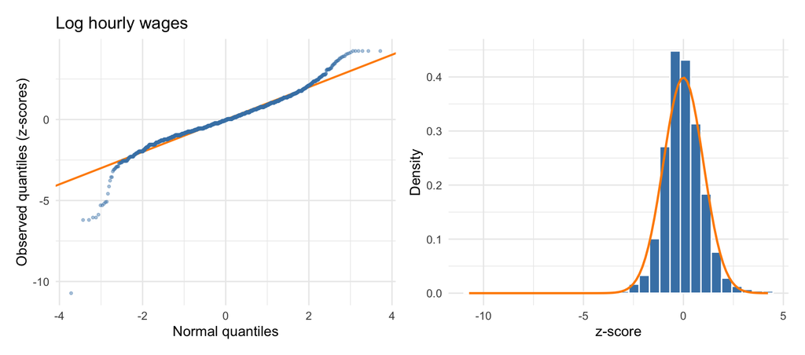

Taking logs pulls the wage points much closer to the line, though the tails remain somewhat heavier than a normal distribution expects.

## QQ plot: daily electricity demand

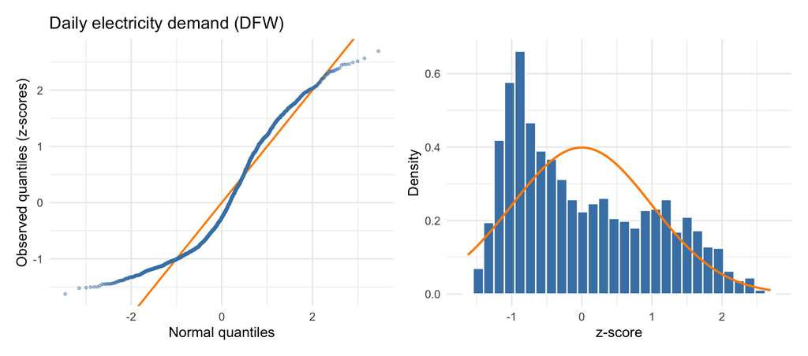